# PSTAT 131: Final Project

Justin Liu

# Main Tasks

- Analyze and visualize the 2020 presidential election results.
- Build and select classification models to predict the election winner.

# Data

We load the necessary packages.

```r
# load packages
library(tidyverse)
library(knitr)
library(kableExtra)
library(corrplot)
library(tree)
library(maptree)
library(glmnet)
library(ROCR)
library(gbm)
library(randomForest)
```

We then load and clean the data.

- The election results at the county level (`election.raw`) are drawn from [here](https://www.kaggle.com/datasets/unanimad/us-election-2020?select=president_county.csv).
- The 2017 United States county-level census data (`census`) is drawn from [here](https://www.kaggle.com/datasets/muonneutrino/us-census-demographic-data).

```r
# read data and convert candidate names and party names from string to factor
# we manually remove the variable "won", the indicator of county level winner
# In Problem 5 we will reproduce this variable!
election.raw <- read_csv("candidates_county.csv", col_names = TRUE) %>%
  mutate(candidate = as.factor(candidate), party = as.factor(party), won = NULL)

# remove the word "County" from the county names
words.to.remove = c("County")
remove.words <- function(str, words.to.remove){
  sapply(str, function(str){
    x <- unlist(strsplit(str, " "))
    x <- x[!x %in% words.to.remove]
    return(paste(x, collapse = " "))
  }, simplify = "array", USE.NAMES = FALSE)
}
election.raw$county <- remove.words(election.raw$county, words.to.remove)

# read census data
census <- read_csv("census_county.csv")
```

# Election data

We take a look at the first few rows of the election data.

```r
# show the first few rows of the election data
election.raw %>%
  head() %>%
  kbl() %>%
  kable_styling(bootstrap_options = c("striped", "hover"))
```

| state | county | candidate | party | total_votes |
| --- | --- | --- | --- | --- |
| Delaware | Kent | Joe Biden | DEM | 44552 |
| Delaware | Kent | Donald Trump | REP | 41009 |
| Delaware | Kent | Jo Jorgensen | LIB | 1044 |
| Delaware | Kent | Howie Hawkins | GRN | 420 |
| Delaware | New Castle | Joe Biden | DEM | 195034 |
| Delaware | New Castle | Donald Trump | REP | 88364 |

**1.** There are 32,177 rows and 5 columns in `election.raw`.

```r
# dimensions of the election data
dim(election.raw)
```

```
## [1] 32177     5
```

There are no missing values in this data set.

```r
# number of missing values in the election data
is.na(election.raw) %>% sum()
```

```
## [1] 0
```

There are 51 distinct values in the `state` column of `election.raw`: all 50 states and 1 federal district (District of Columbia).

```r
# unique states in the election data
unique(election.raw$state)
```

```
##  [1] "Delaware"             "District of Columbia" "Florida"
##  [4] "Georgia"              "Hawaii"               "Idaho"
##  [7] "Illinois"             "Indiana"              "Iowa"
## [10] "Kansas"               "Kentucky"             "Louisiana"
## [13] "Maine"                "Maryland"             "Massachusetts"
## [16] "Michigan"             "Minnesota"            "Mississippi"
## [19] "Missouri"             "Montana"              "Nebraska"
## [22] "Nevada"               "New Hampshire"        "New Jersey"
## [25] "New Mexico"           "New York"             "North Carolina"
## [28] "North Dakota"         "Ohio"                 "Oklahoma"
## [31] "Oregon"               "Pennsylvania"         "Rhode Island"
## [34] "South Carolina"       "South Dakota"         "Tennessee"
## [37] "Texas"                "Utah"                 "Vermont"
## [40] "Virginia"             "Washington"           "West Virginia"
## [43] "Wisconsin"            "Wyoming"              "Alabama"
## [46] "Alaska"               "Arkansas"             "California"
## [49] "Colorado"             "Connecticut"          "Arizona"
```

```r
# number of unique states in the election data
unique(election.raw$state) %>% length()
```

```
## [1] 51
```

# Census data

We take a look at the first few rows of the census data.

```r
# show the first few rows of the census data
census %>%
  head() %>%
  kbl() %>%
  kable_styling(bootstrap_options = c("striped", "hover")) %>%
  scroll_box(width = "100%")
```

| CountyId | State | County | TotalPop | Men | Women | Hispanic | White | Black | Native | Asian | Pacific | VotingAgeCitizen | Income | IncomeErr | IncomePerCap | IncomePerCapErr | Poverty | ChildPoverty | Professional | Service | Office | Construction | Production | Drive | Carpool | Transit | Walk | OtherTransp | WorkAtHome | … |
| --- | --- | --- | --- | --- | --- | --- | --- | --- | --- | --- | --- | --- | --- | --- | --- | --- | --- | --- | --- | --- | --- | --- | --- | --- | --- | --- | --- | --- | --- | --- |
| 1001 | Alabama | Autauga County | 55036 | 26899 | 28137 | 2.7 | 75.4 | 18.9 | 0.3 | 0.9 | 0 | 41016 | 55317 | 2838 | 27824 | 2024 | 13.7 | 20.1 | 35.3 | 18.0 | 23.2 | 8.1 | 15.4 | 86.0 | 9.6 | 0.1 | 0.6 | 1.3 | 2.5 | … |
| 1003 | Alabama | Baldwin County | 203360 | 99527 | 103833 | 4.4 | 83.1 | 9.5 | 0.8 | 0.7 | 0 | 155376 | 52562 | 1348 | 29364 | 735 | 11.8 | 16.1 | 35.7 | 18.2 | 25.6 | 9.7 | 10.8 | 84.7 | 7.6 | 0.1 | 0.8 | 1.1 | 5.6 | … |
| 1005 | Alabama | Barbour County | 26201 | 13976 | 12225 | 4.2 | 45.7 | 47.8 | 0.2 | 0.6 | 0 | 20269 | 33368 | 2551 | 17561 | 798 | 27.2 | 44.9 | 25.0 | 16.8 | 22.6 | 11.5 | 24.1 | 83.4 | 11.1 | 0.3 | 2.2 | 1.7 | 1.3 | … |
| 1007 | Alabama | Bibb County | 22580 | 12251 | 10329 | 2.4 | 74.6 | 22.0 | 0.4 | 0.0 | 0 | 17662 | 43404 | 3431 | 20911 | 1889 | 15.2 | 26.6 | 24.4 | 17.6 | 19.7 | 15.9 | 22.4 | 86.4 | 9.5 | 0.7 | 0.3 | 1.7 | 1.5 | … |
| 1009 | Alabama | Blount County | 57667 | 28490 | 29177 | 9.0 | 87.4 | 1.5 | 0.3 | 0.1 | 0 | 42513 | 47412 | 2630 | 22021 | 850 | 15.6 | 25.4 | 28.5 | 12.9 | 23.3 | 15.8 | 19.5 | 86.8 | 10.2 | 0.1 | 0.4 | 0.4 | 2.1 | … |
| 1011 | Alabama | Bullock County | 10478 | 5616 | 4862 | 0.3 | 21.6 | 75.6 | 1.0 | 0.7 | 0 | 8212 | 29655 | 5376 | 20856 | 2355 | 28.5 | 50.4 | 19.7 | 17.1 | 18.6 | 14.0 | 30.6 | 73.1 | 15.7 | 0.3 | 6.2 | 1.7 | 3.0 | … |

**2.** There are 3,220 rows and 37 columns in `census`.

```r
# dimensions of the census data
dim(census)
```

```
## [1] 3220   37
```

There is 1 missing value in this data set.

```r
# number of missing values in the census data
is.na(census) %>% sum()
```

```
## [1] 1
```

There are 1955 distinct values in the `County` column of `census`.

```r
# number of unique counties in the census data
unique(census$County) %>% length()
```

```
## [1] 1955
```

On the other hand, there are 2825 distinct values in the `county` column of `election.raw`.

```r
# number of unique counties in the election data
unique(election.raw$county) %>% length()
```

```
## [1] 2825
```

We note that there are more distinct counties in `election.raw` than in `census`.

# Data wrangling

**3.** We keep the county-level data as it is in `election.raw`.

```r
# show the first few rows of the dataframe
election.raw %>%
  head() %>%
  kbl() %>%
  kable_styling(bootstrap_options = c("striped", "hover"))
```

| state | county | candidate | party | total_votes |
| --- | --- | --- | --- | --- |
| Delaware | Kent | Joe Biden | DEM | 44552 |
| Delaware | Kent | Donald Trump | REP | 41009 |
| Delaware | Kent | Jo Jorgensen | LIB | 1044 |
| Delaware | Kent | Howie Hawkins | GRN | 420 |
| Delaware | New Castle | Joe Biden | DEM | 195034 |
| Delaware | New Castle | Donald Trump | REP | 88364 |

We create a state-level summary of the total votes for each candidate in `election.state`.

```r
# create a state-level summary of the votes
election.state <- election.raw %>%
  group_by(state, candidate, party) %>%
  summarize(total_votes = sum(total_votes))

# show the first few rows of the dataframe
election.state %>%
  head() %>%
  kbl() %>%
  kable_styling(bootstrap_options = c("striped", "hover"))
```

| state | candidate | party | total_votes |
| --- | --- | --- | --- |
| Alabama | Donald Trump | REP | 1441168 |
| Alabama | Jo Jorgensen | LIB | 25176 |
| Alabama | Joe Biden | DEM | 849648 |
| Alabama | Write-ins | WRI | 7312 |
| Alaska | Brock Pierce | IND | 825 |
| Alaska | Don Blankenship | CST | 1127 |

We create a federal-level summary of the total votes for each candidate in `election.total`.

```r
# create a federal-level summary of the votes
election.total <- election.raw %>%
  group_by(candidate, party) %>%
  summarize(total_votes = sum(total_votes))

# show the first few rows of the dataframe
election.total %>%
  head() %>%
  kbl() %>%
  kable_styling(bootstrap_options = c("striped", "hover"))
```

| candidate | party | total_votes |
| --- | --- | --- |
| Alyson Kennedy | SWP | 6791 |
| Bill Hammons | UTY | 6647 |
| Blake Huber | APV | 409 |
| Brian Carroll | ASP | 25256 |
| Brock Pierce | IND | 49552 |
| Brooke Paige | GOP | 1175 |

**4.** There were 38 unique candidates in the 2020 election.

```r
# number of unique candidates
unique(election.total$candidate) %>% length()
```

```
## [1] 38
```

We create a bar chart of all of the votes received by each candidate. Since Joe Biden and Donald Trump received an overwhelming majority of the votes, the votes have been log-transformed in base 10 to make the bar chart easier to read.

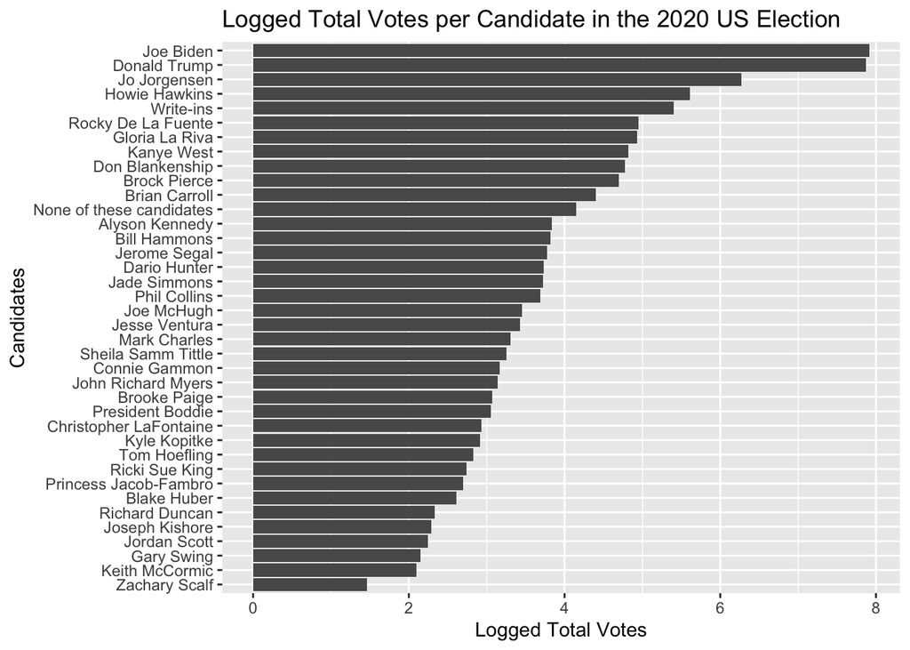

```r
election.total %>%
  # log-transform total votes in base 10
  mutate(log_total_votes = log10(total_votes)) %>%
  # create bar chart
  ggplot(aes(x = reorder(candidate, log_total_votes),
             y = log_total_votes)) +
  geom_bar(stat = "identity") +
  labs(x = "Candidates",
       y = "Logged Total Votes",
       title = "Logged Total Votes per Candidate in the 2020 US Election") +
  coord_flip()
```

**5.** We first get the winner for each county by taking the candidate with the highest proportion of votes at the county level.

```r
# get the winner for each county
county.winner <- election.raw %>%
  group_by(state, county) %>%
  mutate(total = sum(total_votes),
         pct = total_votes / total) %>%
  top_n(1, pct)

# show the first few rows of the dataframe
county.winner %>%
  head() %>%
  kbl() %>%
  kable_styling(bootstrap_options = c("striped", "hover"))
```

| state | county | candidate | party | total_votes | total | pct |
| --- | --- | --- | --- | --- | --- | --- |
| Delaware | Kent | Joe Biden | DEM | 44552 | 87025 | 0.5119448 |
| Delaware | New Castle | Joe Biden | DEM | 195034 | 287633 | 0.6780655 |
| Delaware | Sussex | Donald Trump | REP | 71230 | 129352 | 0.5506679 |
| District of Columbia | District of Columbia | Joe Biden | DEM | 39041 | 41681 | 0.9366618 |
| District of Columbia | Ward 2 | Joe Biden | DEM | 29078 | 32881 | 0.8843405 |
| District of Columbia | Ward 3 | Joe Biden | DEM | 39397 | 44231 | 0.8907101 |

We then get the winner for each state by taking the candidate with the highest proportion of votes at the state level.

```r
# get the winner for each state
state.winner <- election.state %>%
  group_by(state) %>%
  mutate(total = sum(total_votes),
         pct = total_votes / total) %>%
  top_n(1, pct)

# show the first few rows of the dataframe
state.winner %>%
  head() %>%
  kbl() %>%
  kable_styling(bootstrap_options = c("striped", "hover"))
```

| state | candidate | party | total_votes | total | pct |
| --- | --- | --- | --- | --- | --- |
| Alabama | Donald Trump | REP | 1441168 | 2323304 | 0.6203097 |
| Alaska | Donald Trump | REP | 189892 | 391346 | 0.4852279 |
| Arizona | Joe Biden | DEM | 1672143 | 3387326 | 0.4936469 |
| Arkansas | Donald Trump | REP | 760647 | 1219069 | 0.6239573 |
| California | Joe Biden | DEM | 11109764 | 17495906 | 0.6349922 |
| Colorado | Joe Biden | DEM | 1804352 | 3256953 | 0.5540000 |

# Visualization

**6.** We draw a county-level map of the United States below.

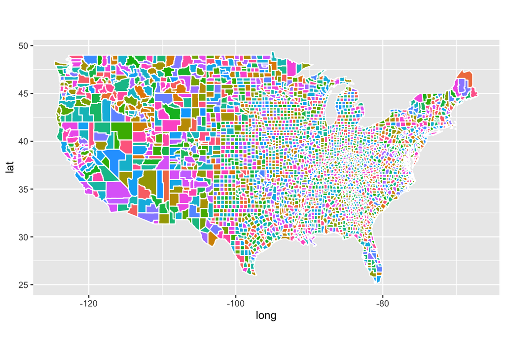

```r
# get dataframe containing county info
counties <- map_data("county")

# plot county-level map
ggplot(data = counties) +
  geom_polygon(aes(x = long, y = lat, fill = subregion, group = group),
               color = "white") +
  coord_fixed(1.3) +
  guides(fill = FALSE)
```

**7.** We color the map of the United States by the winning candidate for each state.

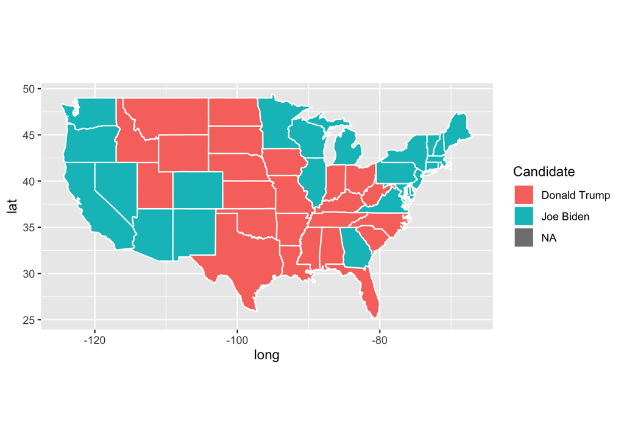

```r
# get dataframe containing state info
states <- map_data("state")

states %>%
  # combine state winners with state info
  mutate(region = str_to_title(region)) %>%
  left_join(state.winner, by = c("region" = "state")) %>%

  # plot state-level map, colored by candidate
  ggplot() +
    geom_polygon(aes(x = long, y = lat, fill = candidate, group = group),
                 color = "white") +
    coord_fixed(1.3) +
    labs(fill = "Candidate")
```

**8.** We color the map of the state of California by the winning candidate for each county.

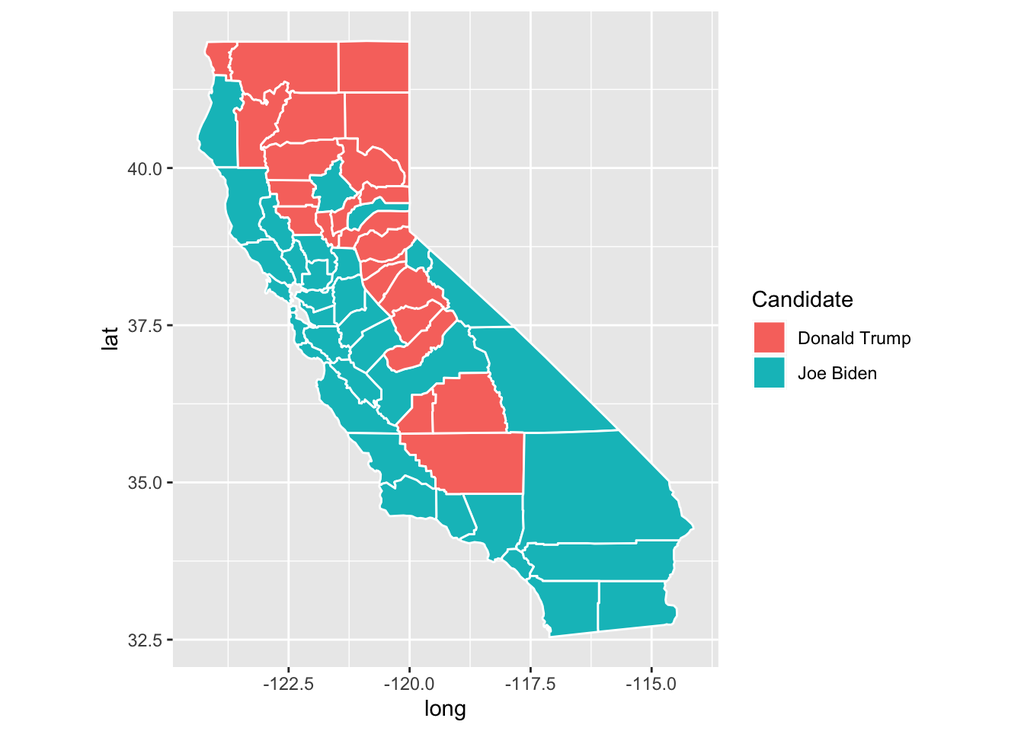

```r
counties %>%
  # make state names uppercase to be able to join dataframes
  mutate(subregion = str_to_title(subregion),
         region = str_to_title(region)) %>%

  # join by both county and state since some states share the same county names
  left_join(county.winner, by = c("region" = "state", "subregion" = "county")) %>%

  # only keep rows for California
  filter(region == "California") %>%

  # plot map of California, colored by candidate
  ggplot() +
    geom_polygon(aes(x = long, y = lat, fill = candidate, group = group),
                 color = "white") +
    coord_fixed(1.3) +
    labs(fill = "Candidate")
```

**9.** We plot the relationship between `white_pct` (% of white people in each state) and `median_income` (median income for each state, averaged over all of its counties) using the data in `census`. Each state in the plot below is represented by a point and is colored by the candidate that won that state. The large points represent the centroids for each group, which are plotted by taking the average of `white_pct` and `median_income` for all of the points in each group.

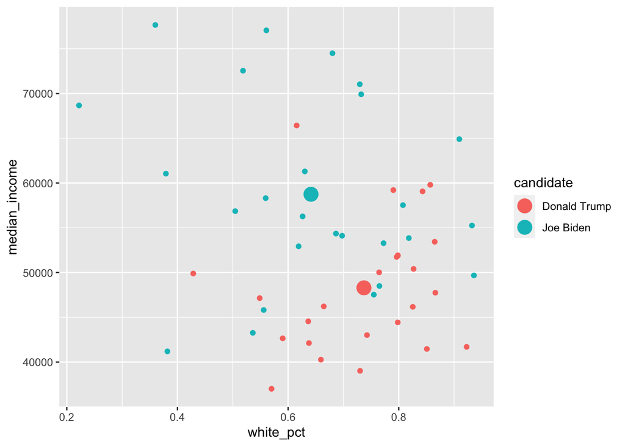

```r
# get the white population percentage and median income of each state
white_income <- census %>%
  mutate(white_pop = TotalPop * White / 100) %>%
  group_by(State) %>%
  summarize(white_pct = sum(white_pop) / sum(TotalPop),
            median_income = mean(Income))

# combine above dataframe with the winners for each state
# exclude Puerto Rico since there is no winning candidate there
white_income_winner <- white_income %>%
  left_join(state.winner, by = c("State" = "state")) %>%
  filter(State != "Puerto Rico")

# calculate centroids for each candidate*
centroids <- white_income_winner %>%
  group_by(candidate) %>%
  summarize(mean_white_pct = mean(white_pct),
            mean_median_income = mean(median_income))

# create scatter plot with candidates as labels*
white_income_winner %>%
  ggplot(aes(x = white_pct, y = median_income, color = candidate)) +
    geom_point() +
    geom_point(data = centroids,
               aes(x = mean_white_pct, y = mean_median_income),
               size = 5)
```

```r
# *credit: https://stackoverflow.com/questions/23463324/r-add-centroids-to-scatter-plot
```

We notice that states that voted for Donald Trump tended to have lower `median_income` and higher `white_pct` compared to states that voted for Joe Biden. However, we would need a statistical test to see if this is actually the case.

**10.** Using the county-level census information stored in `census`, we clean and aggregate the data.

```r
census.clean <- census %>%
  # filter out any rows with missing values
  drop_na() %>%
  # convert Men, Employed, and VotingAgeCitizen to percentages
  # compute Minority by combining columns with minority percentages
  mutate(Men = 100 * Men / TotalPop,
         Employed = 100 * Employed / TotalPop,
         VotingAgeCitizen = 100 * VotingAgeCitizen / TotalPop,
         Minority = Hispanic + Black + Native + Asian + Pacific) %>%
  # remove specified columns
  select(-c(Hispanic, Black, Native, Black, Native, Asian, Pacific,
            IncomeErr, IncomePerCap, IncomePerCapErr, Walk, PublicWork, Construction))
```

We check if there are any highly correlated (numeric) variables.

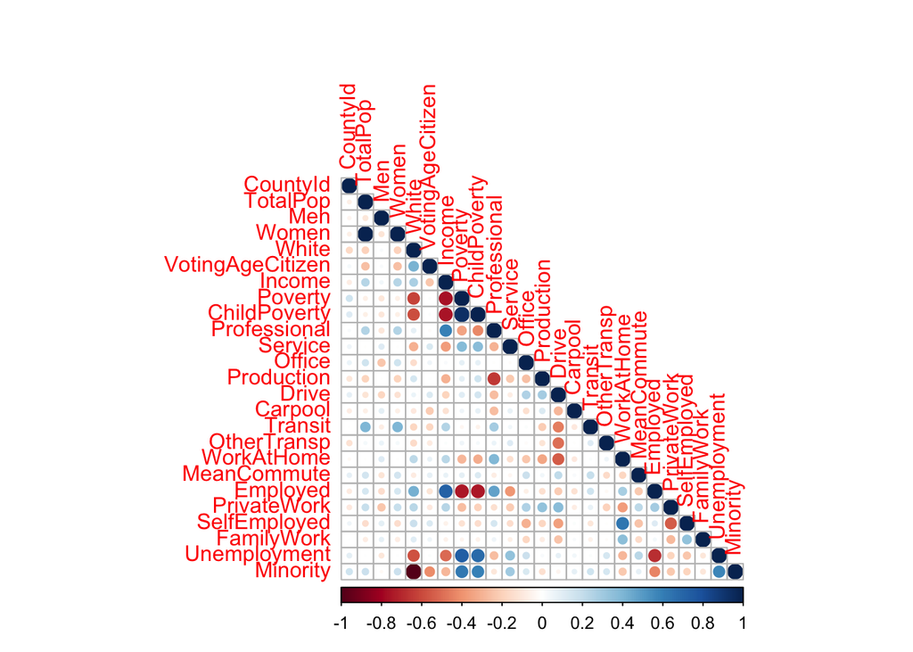

```r
# create correlation matrix
census.clean %>%
  select_if(is.numeric) %>%
  cor() %>%
  corrplot(type = "lower")
```

We notice that there are 3 highly correlated pairs of variables (indicated by the larger and darker red/blue colored circles in the plot above):

- `TotalPop` and `Women`
- `Poverty` and `ChildPoverty`
- `Minority` and `White`

For each of these pairs, we drop one of the variables. We choose to drop `Women`, `ChildPoverty`, and `White`.

```r
# remove highly colinear variables
census.clean <- census.clean %>%
  select(-c(Women, ChildPoverty, White))

# show the first 5 rows of the dataframe
census.clean %>%
  head(5) %>%
  kbl() %>%
  kable_styling(bootstrap_options = c("striped", "hover")) %>%
  scroll_box(width = "100%")
```

| CountyId | State | County | TotalPop | Men | VotingAgeCitizen | Income | Poverty | Professional | Service | Office | Production | Drive | Carpool | Transit | OtherTransp | WorkAtHome | MeanCommute | Employed | PrivateWork | SelfEmployed | FamilyWork | Unemployment | Minority |
| --- | --- | --- | --- | --- | --- | --- | --- | --- | --- | --- | --- | --- | --- | --- | --- | --- | --- | --- | --- | --- | --- | --- | --- |
| 1001 | Alabama | Autauga County | 55036 | 48.87528 | 74.52577 | 55317 | 13.7 | 35.3 | 18.0 | 23.2 | 15.4 | 86.0 | 9.6 | 0.1 | 1.3 | 2.5 | 25.8 | 43.81132 | 74.1 | 5.6 | 0.1 | 5.2 | 22.8 |
| 1003 | Alabama | Baldwin County | 203360 | 48.94129 | 76.40441 | 52562 | 11.8 | 35.7 | 18.2 | 25.6 | 10.8 | 84.7 | 7.6 | 0.1 | 1.1 | 5.6 | 27.0 | 44.02390 | 80.7 | 6.3 | 0.1 | 5.5 | 15.4 |
| 1005 | Alabama | Barbour County | 26201 | 53.34148 | 77.35964 | 33368 | 27.2 | 25.0 | 16.8 | 22.6 | 24.1 | 83.4 | 11.1 | 0.3 | 1.7 | 1.3 | 23.4 | 33.88420 | 74.1 | 6.5 | 0.3 | 12.4 | 52.8 |
| 1007 | Alabama | Bibb County | 22580 | 54.25598 | 78.21966 | 43404 | 15.2 | 24.4 | 17.6 | 19.7 | 22.4 | 86.4 | 9.5 | 0.7 | 1.7 | 1.5 | 30.0 | 36.18689 | 76.0 | 6.3 | 0.3 | 8.2 | 24.8 |
| 1009 | Alabama | Blount County | 57667 | 49.40434 | 73.72154 | 47412 | 15.6 | 28.5 | 12.9 | 23.3 | 19.5 | 86.8 | 10.2 | 0.1 | 0.4 | 2.1 | 35.0 | 37.07493 | 83.9 | 4.0 | 0.1 | 4.9 | 10.9 |

# Dimensionality reduction

**11.** We run PCA for the cleaned county-level census data (with `CountyId`, `State`, and `County` excluded since they are categorical variables) and save the first two principal components `PC1` and `PC2` in `pc.county`.

```r
# run PCA
pc.out <- census.clean %>%
  select(-c(State, County, CountyId)) %>%
  prcomp(scale = TRUE,
         center = TRUE)

# save first 2 PCs
pc.county <- pc.out$x[, 1:2]
```

We centered the features before performing PCA since the input matrix must have columns with mean 0. Since some of the features are on different scales (i.e. `TotalPop` and `Income` are not percentages while the other variables are), we also scaled the features prior to running PCA.

The three features with the largest absolute values of the first principal component (i.e. the loadings) are `Employed`, `Poverty`, and `Income`.

```r
# output 3 largest absolute loadings
pc.out$rotation[, 1] %>%
  abs() %>%
  sort(decreasing = TRUE) %>%
  head(3)
```

```
## Employed  Poverty   Income
## 0.395597 0.393932 0.371292
```

Now we output the loadings for all of the features.

```r
# output all loadings
pc.out$rotation[, 1] %>%
  sort(decreasing = TRUE)
```

```
##         Employed           Income     Professional       WorkAtHome
##      0.395596972      0.371291989      0.313020187      0.276509404
##     SelfEmployed       FamilyWork          Transit         TotalPop
##      0.172604576      0.096451559      0.094238375      0.070127987
##              Men      PrivateWork      OtherTransp VotingAgeCitizen
##      0.023092749      0.019964060      0.008763222     -0.024578317
##          Carpool           Office      MeanCommute       Production
##     -0.070007783     -0.083923200     -0.104454206     -0.154469048
##            Drive          Service         Minority     Unemployment
##     -0.184481228     -0.216126673     -0.257446298     -0.357461574
##          Poverty
##     -0.393932017
```

There are several notable pairs of features that have opposite signs:

- `Employed` & `Unemployment`
- `Income` & `Poverty`
- `Professional` & `Service`
- `Transit` & `Drive`

This implies that these pairs of variables are negatively correlated – as one of these features goes up, the other one goes down.

**12.** The minimum number of PCs needed to capture at least 90% of the variance for the analysis is 13.

```r
# get the proportion of variance explained (PVE) for each PC
pc.var <- pc.out$sdev^2
pve <- pc.var / sum(pc.var)

# minimum number of PCs to capture 90% of the variance in the data
(cumsum(pve) > 0.9) %>%
  which() %>%
  min()
```

```
## [1] 13
```

We plot the PVE and cumulative PVE below. In the cumulative PVE plot,

- the red dashed line indicates where the cumulative PVE captures 90% of the variance in the data, and
- the blue line indicates the minimum number of PCs needed to capture at least 90% of this variance.

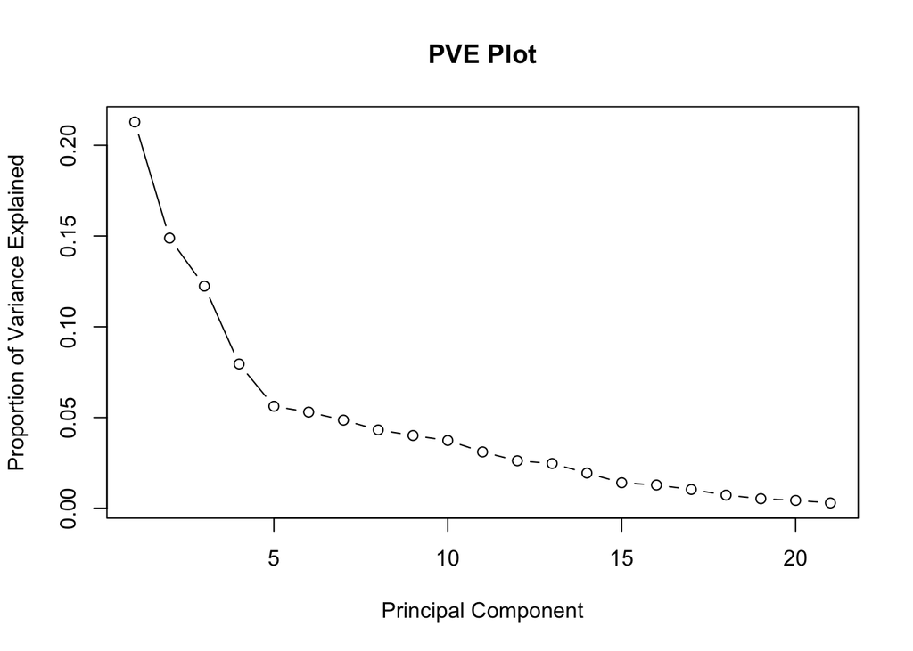

```r
# plot PVE
plot(pve,
     main = "PVE Plot",
     xlab = "Principal Component",
     ylab = "Proportion of Variance Explained",
     type = "b")
```

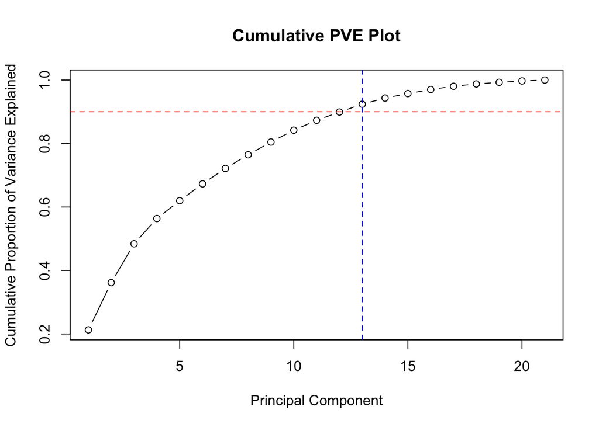

```r
# plot cumulative PVE
plot(cumsum(pve),
     main = "Cumulative PVE Plot",
     xlab = "Principal Component",
     ylab = "Cumulative Proportion of Variance Explained",
     type = "b")

# add lines to show the minimum number of PCs needed to capture 90% variance
abline(h = 0.9, col = "red", lty = "dashed")
abline(v = 13, col = "blue", lty = "dashed")
```

# Clustering

**13.** Using `census.clean` (with `CountyId`, `State`, and `County` excluded since they are categorical variables), we perform hierarchical clustering with complete linkage. The data is scaled beforehand (same reason as in **11**). The observations are then partitioned into 10 clusters.

```r
# get 10 clusters from hierarchical clustering (original data)
hc.original <- census.clean %>%
  select(-c(State, County, CountyId)) %>%
  as.matrix() %>%
  scale() %>%
  dist() %>%
  hclust(method = "complete") %>%
  cutree(10)

# show the number of observations in each cluster
hc.original %>% table()
```

```
## .
##    1    2    3    4    5    6    7    8    9   10
## 2922  213    6   17    5    1   20   30    4    1
```

Note that $2922 / 3219 \approx 90.8\%$ of the observations are classified in one of the clusters, with the next biggest cluster only containing $213 / 3219 \approx 6.6\%$ of the observations. Some of the other clusters have as little as 1 or 2 observations, which aren’t very informative in distinguishing *groups* of observations.

Now we use the first 2 principal components from `pc.county` as inputs instead of the original features. Since we already scaled the features when performing PCA, we do not need to do it here again.

```r
# get 10 clusters from hierarchical clustering (PC data)
hc.pc <- pc.county %>%
  as.matrix() %>%
  dist() %>%
  hclust(method = "complete") %>%
  cutree(10)

# show the number of observations in each cluster
hc.pc %>% table()
```

```
## .
##    1    2    3    4    5    6    7    8    9   10
## 1042  291  519 1086   72   95   24   82    1    7
```

Although the clusters are still unbalanced (the first two biggest clusters contain $1086 / 3129 \approx 33.7\%$ and $1042 / 3219 \approx 32.4\%$ of the observations, respectively), there are more observations in some of the other clusters.

For both of these approaches, we investigate the cluster that contains *Santa Barbara County* (abbreviated from here on out as SB). We make a note of which cluster SB is in for both the original and PC data.

```r
# get index for SB
sb.index <- which(census.clean$County == "Santa Barbara County")

# find which cluster SB is in for both the original and PC clusters
sb.cluster.orig <- hc.original[sb.index]
sb.cluster.pc <- hc.pc[sb.index]

# output clusters
c("Cluster (Original)" = sb.cluster.orig,
  "Cluster (PC)" = sb.cluster.pc)
```

```
## Cluster (Original)       Cluster (PC)
##                  1                  4
```

For the original data, SB is put into a cluster containing 2922 counties (including SB). For the PC data, SB is put into a cluster containing 1086 counties. This is a pretty big difference!

For both the original and PC data, we subset all of the counties in `census.clean` that are in the same cluster as SB and calculate the average values over all of the columns. We then use [cosine similarity](https://en.wikipedia.org/wiki/Cosine_similarity) to measure the similarity between SB and all of the other counties. A number closer to 1 suggests a better classification.

```r
# get all indices for counties that are in the same cluster as SB
ind.orig <- which(hc.original == sb.cluster.orig)
ind.pc <- which(hc.pc == sb.cluster.pc)

# get counties that are in the same cluster as SB (original)
counties.with.sb.orig <- census.clean %>%
  slice(ind.orig) %>%
  filter(County != "Santa Barbara County") %>%
  select(-c(CountyId, State, County)) %>%
  summarise_all(mean)

# get counties that are in the same cluster as SB (PC)
counties.with.sb.pc <- census.clean %>%
  slice(ind.pc) %>%
  filter(County != "Santa Barbara County") %>%
  select(-c(CountyId, State, County)) %>%
  summarise_all(mean)

# define cosine similarity function
cos_sim <- function(df) {
  # get first and second rows of dataframe
  a <- df %>% slice(1)
  b <- df %>% slice(2)
  # calculate cosine similarity between the rows
  sum(a * b) / (sqrt(sum(a^2)) * sqrt(sum(b^2)))
}

# get row for SB
sb <- census.clean %>%
  slice(sb.index) %>%
  select(-c(CountyId, State, County))

# calculate cosine similarity for original data
sb.sim.orig <- sb %>%
  rbind(counties.with.sb.orig) %>%
  cos_sim()

# calculate cosine similarity for PC data
sb.sim.pc <- sb %>%
  rbind(counties.with.sb.pc) %>%
  cos_sim()

# output similarities
c("Similarity (Original)" = sb.sim.orig,
  "Similarity (PC)" = sb.sim.pc)
```

```
## Similarity (Original)       Similarity (PC)
##             0.9366811             0.8415701
```

From the output, it looks using the original data put SB in a slightly more appropriate cluster compared to the PC data. Let’s compare them in the table below.

- The first row is the data for SB (denoted by the row `SB`).
- The second row is the mean data for the counties in the SB cluster using the original data (denoted by the row `Original`).
- The third row is the mean data for the counties in the SB cluster using the PC data (denoted by the row `PC`).

```r
# SB with means of counties in the same cluster
sb %>%
  rbind(counties.with.sb.orig) %>% # 2nd row: original data
  rbind(counties.with.sb.pc) %>%   # 3rd row: PC data
  mutate(Info = c("SB", "Original", "PC")) %>%
  relocate(Info) %>%
  kbl() %>%
  kable_styling(bootstrap_options = c("striped", "hover")) %>%
  scroll_box(width = "100%")
```

| Info | TotalPop | Men | VotingAgeCitizen | Income | Poverty | Professional | Service | Office | Production | Drive | Carpool | Transit | OtherTransp | WorkAtHome | MeanCommute | Employed | PrivateWork | SelfEmployed | FamilyWork | Unemployment | Minority |
| --- | --- | --- | --- | --- | --- | --- | --- | --- | --- | --- | --- | --- | --- | --- | --- | --- | --- | --- | --- | --- | --- |
| SB | 442996.00 | 50.10316 | 63.43376 | 68023.00 | 15.40000 | 35.20000 | 21.70000 | 21.00000 | 8.10000 | 68.00000 | 13.600000 | 3.2000000 | 4.800000 | 5.800000 | 19.40000 | 47.80924 | 75.70000 | 8.100000 | 0.2000000 | 6.600000 | 52.10000 |
| Original | 89744.79 | 50.05419 | 75.17353 | 50214.51 | 15.40527 | 31.44937 | 17.93975 | 21.85847 | 16.13725 | 80.18970 | 9.849812 | 0.7587812 | 1.535502 | 4.638035 | 23.43061 | 44.16196 | 75.71565 | 7.640876 | 0.2525847 | 6.094043 | 19.10181 |
| PC | 52754.88 | 50.41105 | 75.19002 | 46547.77 | 16.40028 | 30.71124 | 19.08359 | 21.24442 | 15.23982 | 78.07226 | 10.783963 | 0.7030415 | 1.773088 | 5.152442 | 22.08599 | 42.62538 | 72.49880 | 8.890783 | 0.3269124 | 6.194286 | 19.63770 |

We note that for a lot of the variables, the values in the row `Original` (compared to `PC`) are relatively closer to `SB`, which resulted in a higher similarity score. It could be that the averages for the original data are much more stable, given that it has more observations than the PC data.

# Classification

We combine `county.winner` and `census.clean` to build the classification models in this section.

```r
# we move all state and county names into lower-case
tmpwinner <- county.winner %>%
  ungroup() %>%
  mutate_at(vars(state, county), tolower)

# we move all state and county names into lower-case
# we further remove suffixes of "county" and "parish"
tmpcensus <- census.clean %>%
  mutate_at(vars(State, County), tolower) %>%
  mutate(County = gsub(" county|  parish", "", County))

# we join the two datasets
election.cl <- tmpwinner %>%
  left_join(tmpcensus, by = c("state" = "State", "county" = "County")) %>%
  na.omit()

# drop levels of county winners if you haven't done so in previous parts
election.cl$candidate <- droplevels(election.cl$candidate)

## save meta information
election.meta <- election.cl %>%
  select(c(county, party, CountyId, state, total_votes, pct, total))

## save predictors and class labels
election.cl <- election.cl %>%
  select(-c(county, party, CountyId, state, total_votes, pct, total))
```

**14.** In the code above, we exclude the predictor `party` from `election.cl` because the political candidate’s party would perfectly predict the correct candidate (i.e. `DEM` would always predict `Joe Biden` while `REP` would always predict `Donald Trump`). This wouldn’t be an informative model as the other variables are not taken into account.

Before creating our classification models, we partition the data into 80% training and 20% testing.

```r
set.seed(10)
n <- nrow(election.cl)
idx.tr <- sample.int(n, 0.8*n)
election.tr <- election.cl[idx.tr, ]
election.te <- election.cl[-idx.tr, ]
```

We then define the 10 cross-validation folds.

```r
set.seed(20)
nfold <- 10
folds <- sample(cut(1:nrow(election.tr),
                    breaks = nfold,
                    labels = FALSE))
```

We also define a classification error rate function and create a matrix called `records` to store the classification performances for several methods (in the next few problems).

```r
calc_error_rate <- function(predicted.value, true.value){
  return(mean(true.value != predicted.value))
}

records <- matrix(NA, nrow = 3, ncol = 2)
colnames(records) <- c("train.error", "test.error")
rownames(records) <- c("tree", "logistic", "lasso")
```

**15.** We train a decision tree with `candidate` as the response and prune the tree using 10-fold cross validation to minimize the misclassification error.

```r
# construct decision tree
election.tree <- tree(candidate ~ .,
                      election.tr)

# use 10-fold CV to determine best tree size
cv <- cv.tree(election.tree,
              rand = folds,
              FUN = prune.misclass,
              K = 10)
best.cv <- min(cv$size[cv$dev == min(cv$dev)])

# prune the tree
election.tree.pruned <- prune.misclass(election.tree,
                                       best = best.cv)
```

We then visualize the trees before and after pruning.

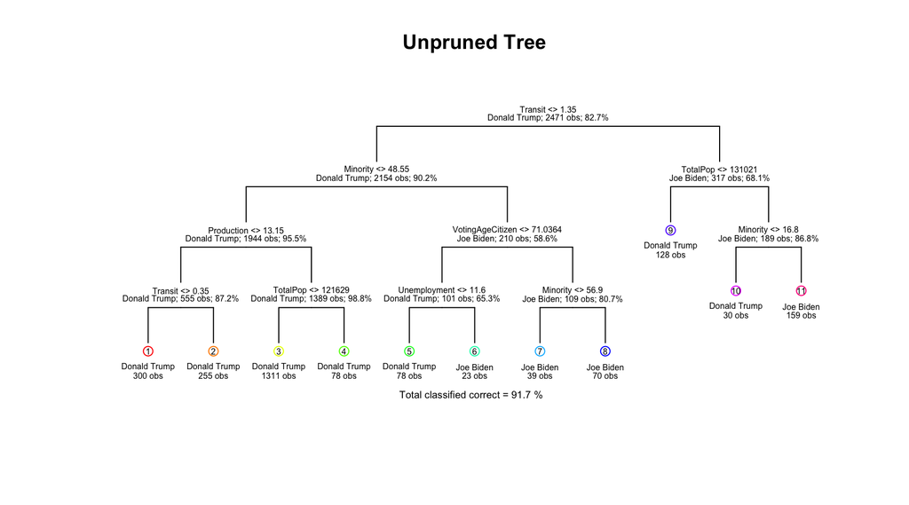

```r
# draw the unpruned tree
draw.tree(election.tree,
          nodeinfo = TRUE,
          cex = 0.5)
title("Unpruned Tree")
```

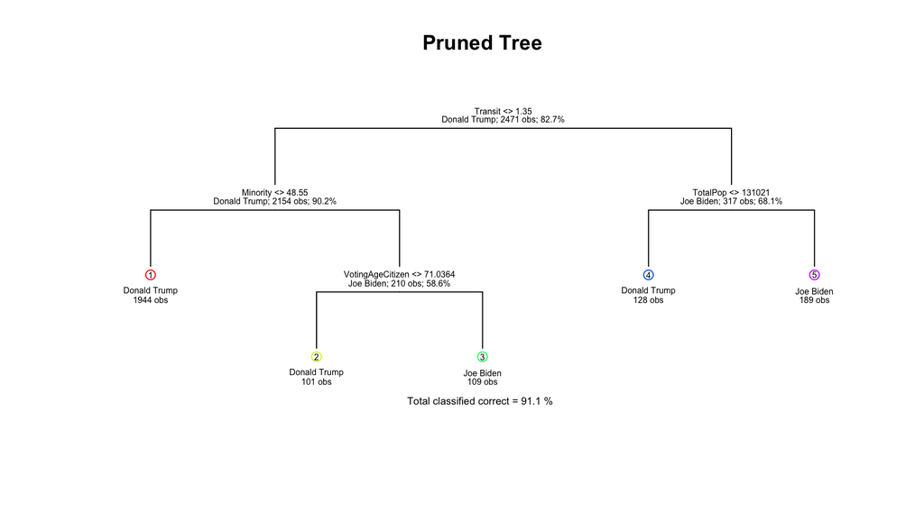

```r
# draw the pruned tree
draw.tree(election.tree.pruned,
          nodeinfo = TRUE,
          cex = 0.5)
title("Pruned Tree")
```

Now we find the training and test errors for the pruned tree and save the results in `records`.

```r
# get actual labels
actual.class.train <- election.tr %>% pull(candidate)
actual.class.test <- election.te %>% pull(candidate)

# get training and test predictions
pred.class.train <- predict(election.tree.pruned, election.tr, type = "class")
pred.class.test <- predict(election.tree.pruned, election.te, type = "class")

# calculate training and test errors
train.error <- calc_error_rate(pred.class.train, actual.class.train)
test.error <- calc_error_rate(pred.class.test, actual.class.test)

# save results
records[1, 1] <- train.error
records[1, 2] <- test.error

# display results
c("Training error rate" = train.error,
  "Test error rate" = test.error)
```

```
## Training error rate     Test error rate
##          0.08943747          0.09385113
```

**16.** We run a logistic regression model with `candidate` as the response.

```r
# fit logistic regression mmodel
glm.model <- glm(candidate ~ .,
                 data = election.tr,
                 family = "binomial")
```

```
## Warning: glm.fit: fitted probabilities numerically 0 or 1 occurred
```

Note that there is a warning `glm.fit: fitted probabilities numerically 0 or 1 occurred`, which indicates that we have perfect separation (some linear combination of variables perfectly predicts the winner). This is a sign of overfitting.

Now we find the training and test errors for the logistic regression model and save the results in `records`.

```r
# get training predictions
pred.prob.train <- predict(glm.model, election.tr, type = "response")
pred.class.train <- ifelse(pred.prob.train > 0.5, "Joe Biden", "Donald Trump")

# get test predictions
pred.prob.test <- predict(glm.model, election.te, type = "response")
pred.class.test <- ifelse(pred.prob.test > 0.5, "Joe Biden", "Donald Trump")

# calculate training and test errors
train.error <- calc_error_rate(pred.class.train, actual.class.train)
test.error <- calc_error_rate(pred.class.test, actual.class.test)

# save results
records[2, 1] <- train.error
records[2, 2] <- test.error

# display results
c("Training error rate" = train.error,
  "Test error rate" = test.error)
```

```
## Training error rate     Test error rate
##          0.06839336          0.06310680
```

Below, we show a summary of the fitted logistic regression model.

```r
# show summary of logistic regression model
summary(glm.model)
```

```
##
## Call:
## glm(formula = candidate ~ ., family = "binomial", data = election.tr)
##
## Deviance Residuals:
##     Min       1Q   Median       3Q      Max
## -4.5750  -0.2491  -0.1028  -0.0352   3.3537
##
## Coefficients:
##                    Estimate Std. Error z value Pr(>|z|)
## (Intercept)      -5.137e+01  6.413e+00  -8.011 1.14e-15 ***
## TotalPop          1.805e-06  6.250e-07   2.888  0.00388 **
## Men               1.776e-02  4.312e-02   0.412  0.68043
## VotingAgeCitizen  1.824e-01  2.499e-02   7.299 2.90e-13 ***
## Income           -9.016e-06  1.604e-05  -0.562  0.57397
## Poverty           5.020e-02  2.824e-02   1.778  0.07547 .
## Professional      3.014e-01  3.726e-02   8.090 5.99e-16 ***
## Service           3.420e-01  4.426e-02   7.727 1.10e-14 ***
## Office            1.328e-01  4.505e-02   2.948  0.00320 **
## Production        1.865e-01  3.971e-02   4.698 2.63e-06 ***
## Drive            -1.020e-01  3.496e-02  -2.916  0.00354 **
## Carpool          -7.161e-02  4.630e-02  -1.547  0.12197
## Transit           2.534e-01  8.702e-02   2.912  0.00360 **
## OtherTransp       1.478e-01  8.749e-02   1.690  0.09108 .
## WorkAtHome        6.583e-02  5.917e-02   1.113  0.26588
## MeanCommute       3.681e-02  2.287e-02   1.610  0.10748
## Employed          2.604e-01  3.127e-02   8.328  < 2e-16 ***
## PrivateWork       4.452e-02  1.983e-02   2.245  0.02478 *
## SelfEmployed     -3.225e-02  4.202e-02  -0.767  0.44280
## FamilyWork       -4.522e-01  2.749e-01  -1.645  0.09993 .
## Unemployment      2.549e-01  4.259e-02   5.986 2.15e-09 ***
## Minority          1.231e-01  8.887e-03  13.847  < 2e-16 ***
## ---
## Signif. codes:  0 '***' 0.001 '**' 0.01 '*' 0.05 '.' 0.1 ' ' 1
##
## (Dispersion parameter for binomial family taken to be 1)
##
##     Null deviance: 2274.83  on 2470  degrees of freedom
## Residual deviance:  857.37  on 2449  degrees of freedom
## AIC: 901.37
##
## Number of Fisher Scoring iterations: 7
```

The significant variables (under a significance level of $\alpha = 0.05$) are `TotalPop`, `VotingAgeCitizen`, `Professional`, `Service`, `Office`, `Production`, `Drive`, `Transit`, `Employed`, `PrivateWork`, `Unemployment`, and `Minority`. Compared to the decision tree, the logistic regression model has considerably more significant features (though they do share `Transit`, `Minority`, `TotalPop`, and `VotingAgeCitizen`). Here is an interpretation of some of these variables:

- An increase in 1 unit (person) of `TotalPop` increases the log-odds of voting for Joe Biden by $1.805 \times 10^{-6}$.
- An increase in 1 unit (year) of `VotingAgeCitizen` increases the log-odds of voting for Joe Biden by $1.824 \times 10^{-1}$.
- An increase in 1 unit (percent) of `Drive` decreases the log-odds of voting for Joe Biden by $-1.020 \times 10^{-1}$.

**17.** To control overfitting in logistic regression, we use regularization. We use the `cv.glmnet()` function to run a 10-fold cross validation and select the best regularization parameter for the logistic regression model with LASSO penalty. The optimal value of the tuning parameter is $\lambda = 0.0005$.

```r
# set values for lambda
lambda <- seq(1, 50) * 1e-4

# create the input matrices
x.train <- model.matrix(candidate ~ ., election.tr)
y.train <- election.tr %>% pull(candidate)

# fit LASSO logistic regression model
lasso.mod <- glmnet(x.train,
                    y.train,
                    alpha = 1,
                    family = "binomial")

# run 10-fold CV
cv.out.lasso <- cv.glmnet(x.train,
                          y.train,
                          alpha = 1,
                          nfolds = 10,
                          foldid = folds,
                          lambda = lambda,
                          family = "binomial")

# best value of lambda
(best.lambda.lasso <- cv.out.lasso$lambda.min)
```

```
## [1] 5e-04
```

```r
predict(lasso.mod,
        type = "coefficients",
        s = best.lambda.lasso)
```

```
## 23 x 1 sparse Matrix of class "dgCMatrix"
##                             s1
## (Intercept)      -4.710136e+01
## (Intercept)       .
## TotalPop          1.840948e-06
## Men               5.567658e-04
## VotingAgeCitizen  1.801980e-01
## Income           -8.546605e-07
## Poverty           5.352856e-02
## Professional      2.702057e-01
## Service           3.091024e-01
## Office            1.082291e-01
## Production        1.570251e-01
## Drive            -9.603647e-02
## Carpool          -6.557266e-02
## Transit           2.369976e-01
## OtherTransp       1.388665e-01
## WorkAtHome        5.496693e-02
## MeanCommute       2.724789e-02
## Employed          2.401481e-01
## PrivateWork       4.222275e-02
## SelfEmployed     -3.089126e-02
## FamilyWork       -4.202773e-01
## Unemployment      2.399377e-01
## Minority          1.180266e-01
```

Now we find the training and test errors for the LASSO logistic regression model and save the results in `records`.

```r
# get training predictions
pred.class.train <- predict(lasso.mod,
                            newx = x.train,
                            type = "class",
                            s = best.lambda.lasso)


# get test predictions
x.test <- model.matrix(candidate ~ ., election.te)
pred.class.test <- predict(lasso.mod,
                           newx = x.test,
                           type = "class",
                           s = best.lambda.lasso)

# calculate training and test errors
train.error <- calc_error_rate(pred.class.train, actual.class.train)
test.error <- calc_error_rate(pred.class.test, actual.class.test)

# save results
records[3, 1] <- train.error
records[3, 2] <- test.error

# display results
c("Training error rate" = train.error,
  "Test error rate" = test.error)
```

```
## Training error rate     Test error rate
##          0.06798867          0.06472492
```

**18.** According to the ROC plot below, the logistic regression models have around the same performance while the decision tree performed considerably worse. The decision tree has better interpretability (as seen in **15**), though its main disadvantage is that it tends to have higher variance compared to other methods. On the other hand, both of the logistic regression models yield higher accuracies on the test data, though the models are less intuitive compared to a decision tree. Therefore, the decision tree is better for inference (determining the factors that lead a state to favor one candidate over another) while the logistic regression models are better for prediction (determining what candidate is more likely to choose based on given data).

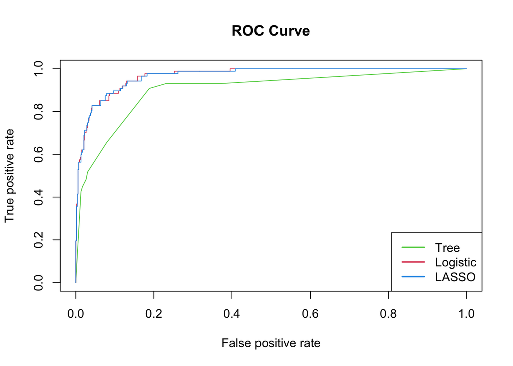

```r
# get test probabilities from the decision tree
tree.pred.prob <- predict(election.tree,
                          election.te,
                          type = "vector")[, 2]

# get test probabilities from the logistic regression model
log.reg.prob <- predict(glm.model,
                        election.te,
                        type = "response")

# get test probabilities from the LASSO logistic regression model
lasso.prob <- predict(lasso.mod,
                      newx = x.test,
                      type = "response",
                      s = best.lambda.lasso)

# plot ROC for decision tree
prediction(tree.pred.prob, actual.class.test) %>%
  performance(measure = "tpr", x.measure = "fpr") %>%
  plot(col = 3, lwd = 1, main = "ROC Curve")

# plot ROC for logistic regression model
prediction(log.reg.prob, actual.class.test) %>%
  performance(measure = "tpr", x.measure = "fpr") %>%
  plot(add = TRUE, col = 2, lwd = 1)

# plot ROC for LASSO logistic regression model
prediction(lasso.prob, actual.class.test) %>%
  performance(measure = "tpr", x.measure = "fpr") %>%
  plot(add = TRUE, col = 4, lwd = 1)

# add legend
legend("bottomright",
       legend = c("Tree", "Logistic", "LASSO"),
       lty = 1,
       col = c(3, 2, 4),
       lwd = 2)
```

# Taking it further

**19.** We first fit a boosted model with 1000 trees using our training set.

```r
# fit boosted model
set.seed(1)
election.boost <- gbm(ifelse(candidate == "Joe Biden", 1, 0) ~ .,
                      data = election.tr,
                      distribution = "bernoulli",
                      interaction.depth = 3,
                      n.trees = 1000)

# show important variables
summary(election.boost, plot = FALSE) %>%
  kbl() %>%
  kable_styling(bootstrap_options = c("striped", "hover"))
```

|  | var | rel.inf |
| --- | --- | --- |
| Transit | Transit | 23.8619427 |
| Minority | Minority | 21.7810211 |
| TotalPop | TotalPop | 9.6717645 |
| VotingAgeCitizen | VotingAgeCitizen | 5.7725185 |
| Professional | Professional | 5.3147203 |
| Unemployment | Unemployment | 4.0155365 |
| Employed | Employed | 3.9106681 |
| Service | Service | 3.7755748 |
| Income | Income | 3.3689717 |
| Production | Production | 2.8409796 |
| Men | Men | 2.4190495 |
| Drive | Drive | 2.3116110 |
| SelfEmployed | SelfEmployed | 1.6358595 |
| WorkAtHome | WorkAtHome | 1.6140217 |
| Office | Office | 1.5516305 |
| MeanCommute | MeanCommute | 1.4412183 |
| PrivateWork | PrivateWork | 1.3566656 |
| Poverty | Poverty | 1.3409429 |
| OtherTransp | OtherTransp | 1.0230588 |
| Carpool | Carpool | 0.7584450 |
| FamilyWork | FamilyWork | 0.2337993 |

In the boosted model, we note that `Transit`, `Minority`, and `TotalPop` are the most important variables, which we also saw in our decision tree.

Now we try fitting a random forest with 1000 trees.

```r
# fit random forest model
set.seed(1)
election.rf <- randomForest(candidate ~ .,
                            data = election.tr,
                            ntree = 1000,
                            importance = TRUE)

# show summary
election.rf
```

```
##
## Call:
##  randomForest(formula = candidate ~ ., data = election.tr, ntree = 1000,      importance = TRUE)
##                Type of random forest: classification
##                      Number of trees: 1000
## No. of variables tried at each split: 4
##
##         OOB estimate of  error rate: 6.48%
## Confusion matrix:
##              Donald Trump Joe Biden class.error
## Donald Trump         1998        46  0.02250489
## Joe Biden             114       313  0.26697892
```

Overall, the random forest model tends to predict Donald Trump more often than Joe Biden. Although there aren’t a lot of misclassifications for Donald Trump (2.3% error rate), there are considerably more misclassifications for Joe Biden (26.7% error rate).

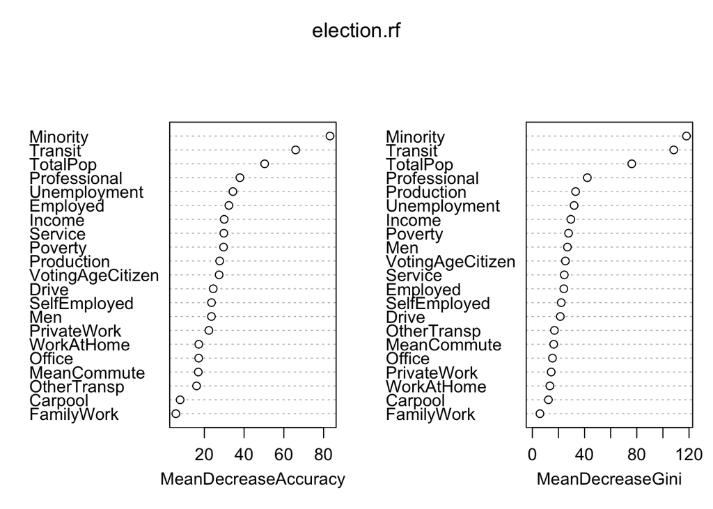

```r
# show important variables
varImpPlot(election.rf)
```

In the random forest model, we note that `Transit`, `Minority`, and `TotalPop` are the most important variables. These seem to be pretty consistent in our analysis.

Now let’s calculate the training and test error rates for each of these tree methods.

```r
# get training predictions
pred.prob.train <- predict(election.boost,
                           newdata = election.tr,
                           n.trees = 1000,
                           type = "response")
pred.class.train <- ifelse(pred.prob.train > 0.5, "Joe Biden", "Donald Trump")

# get test predictions
pred.prob.test <- predict(election.boost,
                          newdata = election.te,
                          n.trees = 1000,
                          type = "response")
pred.class.test <- ifelse(pred.prob.test > 0.5, "Joe Biden", "Donald Trump")

# calculate training and test errors
train.error <- calc_error_rate(pred.class.train, actual.class.train)
test.error <- calc_error_rate(pred.class.test, actual.class.test)

# display results
c("Training error rate (Boosted)" = train.error,
  "Test error rate (Boosted)" = test.error)
```

```
## Training error rate (Boosted)     Test error rate (Boosted)
##                    0.00000000                    0.05016181
```

```r
# get training predictions
pred.prob.train <- predict(election.rf,
                           election.tr,
                           type = "prob")[, 2]
pred.class.train <- ifelse(pred.prob.train > 0.5, "Joe Biden", "Donald Trump")

# get test predictions
pred.prob.test <- predict(election.rf,
                          election.te,
                          type = "prob")[, 2]
pred.class.test <- ifelse(pred.prob.test > 0.5, "Joe Biden", "Donald Trump")

# calculate training and test errors
train.error <- calc_error_rate(pred.class.train, actual.class.train)
test.error <- calc_error_rate(pred.class.test, actual.class.test)

# display results
c("Training error rate (Random Forest)" = train.error,
  "Test error rate (Random Forest)" = test.error)
```

```
## Training error rate (Random Forest)     Test error rate (Random Forest)
##                           0.0000000                           0.0631068
```

Interestingly, both models have a training error rate of 0%, which is most likely a sign of overfitting. In terms of the test error rate, the boosted model performs slightly better than the random forest model. Now we plot the ROC curves for both of these models, along with the 3 other models we used earlier.

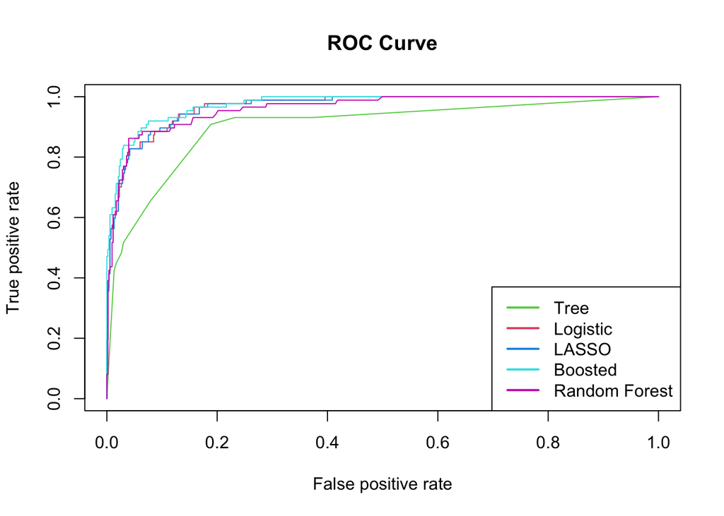

```r
# get test probabilities from the boosted model
boost.prob <- predict(election.boost,
                      newdata = election.te,
                      n.trees = 1000,
                      type = "response")

# get test probabilities from the random forest model
rf.prob <- predict(election.rf,
                   election.te,
                   type = "prob")[, 2]

# plot ROC for decision tree
prediction(tree.pred.prob, actual.class.test) %>%
  performance(measure = "tpr", x.measure = "fpr") %>%
  plot(col = 3, lwd = 1, main = "ROC Curve")

# plot ROC for logistic regression model
prediction(log.reg.prob, actual.class.test) %>%
  performance(measure = "tpr", x.measure = "fpr") %>%
  plot(add = TRUE, col = 2, lwd = 1)

# plot ROC for LASSO logistic regression model
prediction(lasso.prob, actual.class.test) %>%
  performance(measure = "tpr", x.measure = "fpr") %>%
  plot(add = TRUE, col = 4, lwd = 1)

# plot ROC for boosted model
prediction(boost.prob, actual.class.test) %>%
  performance(measure = "tpr", x.measure = "fpr") %>%
  plot(add = TRUE, col = 5, lwd = 1)

# plot ROC for random forest model
prediction(rf.prob, actual.class.test) %>%
  performance(measure = "tpr", x.measure = "fpr") %>%
  plot(add = TRUE, col = 6, lwd = 1)

# add legend
legend("bottomright",
       legend = c("Tree", "Logistic", "LASSO", "Boosted", "Random Forest"),
       lty = 1,
       col = c(3, 2, 4, 5, 6),
       lwd = 2)
```

From the plot above, we see that the boosted model appears to perform the best. However, both the boosted and random forest model aren’t as easily interpretable as the other methods, so they are usually better for prediction than inference.

**20.** Unemployment was an important issue during the 2020 election, especially due to the prevalence of COVID-19. According to the [New York Times](https://www.nytimes.com/interactive/2020/11/16/business/economy/unemployment-election-counties.html), counties that that had higher unemployment rates were more likely to vote for Biden. What if the unemployment rate was the response instead of a predictor?

We try using forward and backward selection to see if we can get a suitable subset of predictors. The full model with all of the predictors is our baseline model.

```r
# full model
full.lm <- lm(Unemployment ~ ., data = election.tr)

# backward stepwise regression
backward.lm <- step(full.lm,
                    direction = "backward",
                    trace = 0)

# forward stepwise regression
forward.lm <- step(full.lm,
                   direction = "forward",
                   trace = 0)

# adjusted R2 for a model
adj.R2 <- function(model) {
  summary(model)$adj.r.squared
}

# gets the number of parameters in a model
param <- function(model) {
  coef(model) %>% length()
}

# output results
data.frame(model = c("full", "backward", "forward"),
           parameters = c(param(full.lm), param(backward.lm), param(forward.lm)),
           AIC = c(AIC(full.lm), AIC(backward.lm), AIC(forward.lm)),
           BIC = c(BIC(full.lm), BIC(backward.lm), BIC(forward.lm)),
           adj.R2 = c(adj.R2(full.lm), adj.R2(backward.lm), adj.R2(forward.lm))) %>%
  kbl() %>%
  kable_styling(bootstrap_options = c("striped", "hover"))
```

| model | parameters | AIC | BIC | adj.R2 |
| --- | --- | --- | --- | --- |
| full | 22 | 10298.07 | 10431.75 | 0.5875669 |
| backward | 19 | 10294.33 | 10410.58 | 0.5876935 |
| forward | 22 | 10298.07 | 10431.75 | 0.5875669 |

The forward stepwise regression model doesn’t differ from the model – both have all 22 predictors. However, the backward stepwise regression model has 19 predictors, not to mention a lower AIC, lower BIC, and a higher adjusted $R^2$ value.

Taking a look at the backward model, we note that `TotalPop`, `Professional`, and `FamilyWork` were dropped from the model, making all of the predictors significant under $\alpha = 0.10$.

```r
# show summary of backward model
summary(backward.lm)
```

```
##
## Call:
## lm(formula = Unemployment ~ candidate + Men + VotingAgeCitizen +
##     Income + Poverty + Service + Office + Production + Drive +
##     Carpool + Transit + OtherTransp + WorkAtHome + MeanCommute +
##     Employed + PrivateWork + SelfEmployed + Minority, data = election.tr)
##
## Residuals:
##     Min      1Q  Median      3Q     Max
## -9.7977 -0.9534 -0.0438  0.9117 19.4730
##
## Coefficients:
##                      Estimate Std. Error t value Pr(>|t|)
## (Intercept)         1.379e+01  2.570e+00   5.365 8.86e-08 ***
## candidateJoe Biden  8.750e-01  1.387e-01   6.308 3.35e-10 ***
## Men                -1.802e-01  1.869e-02  -9.641  < 2e-16 ***
## VotingAgeCitizen    3.084e-02  1.081e-02   2.854 0.004360 **
## Income              2.423e-05  6.668e-06   3.634 0.000285 ***
## Poverty             1.217e-01  1.247e-02   9.757  < 2e-16 ***
## Service             5.678e-02  1.377e-02   4.125 3.84e-05 ***
## Office              4.136e-02  1.625e-02   2.546 0.010964 *
## Production          3.632e-02  1.050e-02   3.459 0.000551 ***
## Drive               3.404e-02  1.763e-02   1.931 0.053584 .
## Carpool             6.090e-02  2.280e-02   2.672 0.007598 **
## Transit             4.237e-02  2.531e-02   1.674 0.094178 .
## OtherTransp         9.970e-02  4.117e-02   2.422 0.015522 *
## WorkAtHome          8.347e-02  2.755e-02   3.030 0.002475 **
## MeanCommute         3.463e-02  9.277e-03   3.733 0.000194 ***
## Employed           -2.102e-01  1.166e-02 -18.027  < 2e-16 ***
## PrivateWork        -2.129e-02  8.743e-03  -2.435 0.014965 *
## SelfEmployed       -1.061e-01  1.715e-02  -6.183 7.34e-10 ***
## Minority            1.654e-02  3.332e-03   4.964 7.38e-07 ***
## ---
## Signif. codes:  0 '***' 0.001 '**' 0.01 '*' 0.05 '.' 0.1 ' ' 1
##
## Residual standard error: 1.935 on 2452 degrees of freedom
## Multiple R-squared:  0.5907, Adjusted R-squared:  0.5877
## F-statistic: 196.6 on 18 and 2452 DF,  p-value: < 2.2e-16
```

Although not many predictors were dropped from the full model, the backward model is still comparable in predicting unemployment rates for each county, as seen with the sum of squared residuals (SSR) on the test data below.

```r
# predicted values using the full and backward models
pred.full <- predict(full.lm, election.te)
pred.backward <- predict(backward.lm, election.te)

# actual values
actual <- election.te %>% pull(Unemployment)

# SSR of test data using the full model and backward models
ssr.full <- mean((pred.full - actual)^2)
ssr.backward <- mean((pred.backward - actual)^2)

# output SSR
c("SSR of full model" = ssr.full,
  "SSR of backward model" = ssr.backward)
```

```
##     SSR of full model SSR of backward model
##              3.446009              3.425429
```